# SunPy - Python for Solar Physics

## Stuart Mumford

## The University of Sheffield, UK

[figure not shown]

## Things you should know:

1. *You* can use SunPy for your research. (probably)
2. You should join the SunPy community.

Slides here: http://stuartmumford.uk/talks/ras2016/

## What is SunPy?

> "A Project to facilitate and promote the use and development of a community-led, free and open-source solar data-analysis software based on the scientific Python environment."

A library designed to provide core functionality to enable people to do solar physics with Python.

A community of solar physicists doing science using Python.

## Why Python?

1. Python is being widely adopted as a *scientific* programming language.
2. Easy to learn.
3. A lot of new astronomical code is being written in Python, *i.e.* JWST & DKIST pipelines.
4. A lot of domain experts write packages in Python, that *you* can use!
5. Python is widely used outside of acedemia.
6. A *very* transferable skill.
7. Very flexible, can wrap C or FORTRAN code when you have a need for speed.
8. many many more...

## SunPy is a Gateway

[figure not shown]

## Major Features of SunPy

- Data Structures for Images, Spectra, and Time Series Data.
- Data Retrival code, from VSO, JSOC, HEK, Helio, and other places.
- Versioned Library Releases, with clear upgrade paths.
- High quality documentation.

## A Plot!

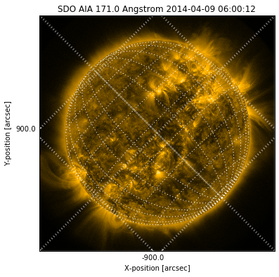

```python
# Create a AIA 171 Map from some sample data
mymap = sunpy.map.Map(AIA_171_ROLL_IMAGE)

# Plot the AIA Map object
im = mymap.plot()

#Make the HP grid larger so it can be seen on the projector
plt.gca().coords.grid(color='white', lw=3)

# Overlay the Heliographic Coordinate Grid
l = mymap.draw_grid()
```

## Searching the VSO

```python
from sunpy.net import vso
from sunpy.net.vso import attrs as a

vc = vso.VSOClient()
results = vc.query(a.Time('2015/12/1T00:00:20', '2015/12/1T00:00:25'),
                   a.Instrument('AIA') | a.Instrument('HMI'))
results
```

<Table masked=False length=7>

| Start Time [1] string152 | End Time [1] string152 | Source string24 | Instrument string24 | Type string64 |
| --- | --- | --- | --- | --- |
| 2015-12-01 00:00:22 | 2015-12-01 00:00:23 | SDO | AIA | FULLDISK |
| 2015-12-01 00:00:22 | 2015-12-01 00:00:23 | SDO | AIA | FULLDISK |
| 2015-12-01 00:00:24 | 2015-12-01 00:00:25 | SDO | AIA | FULLDISK |
| 2015-12-01 00:00:25 | 2015-12-01 00:00:26 | SDO | AIA | FULLDISK |
| 2015-12-01 00:00:24 | 2015-12-01 00:00:25 | SDO | HMI | FULLDISK |
| 2015-12-01 00:00:24 | 2015-12-01 00:00:25 | SDO | HMI | FULLDISK |
| 2015-12-01 00:00:24 | 2015-12-01 00:00:25 | SDO | HMI | FULLDISK |

```python
vc.get(results, path="/home/stuart/sunpy/data/{instrument}/{file}").wait()
```

## SunPy Needs You

### https://github.com/sunpy/sunpy

[figure not shown]

## Workshops

- Software Carpentry style workshops, with extra days for SunPy and Astropy.
- First one March 2015.
- Next one next week! (Still spaces)
- Material online (https://github.com/OpenAstronomy/workshop_sunpy_astropy).
- We will run one for you!

[figure not shown]

## Links

- https://sunpy.org
- https://groups.google.com/forum/#!forum/sunpy
- https://github.com/sunpy
- http://stuartmumford.uk/talks/ras2016/
- http://openastronomy.org/
- http://openastronomy.org/2016-01-11-Sheffield/
- https://github.com/OpenAstronomy/workshop_sunpy_astropy